# Assignment: Homework Hyndman Chapter 5 & 6 Exercises

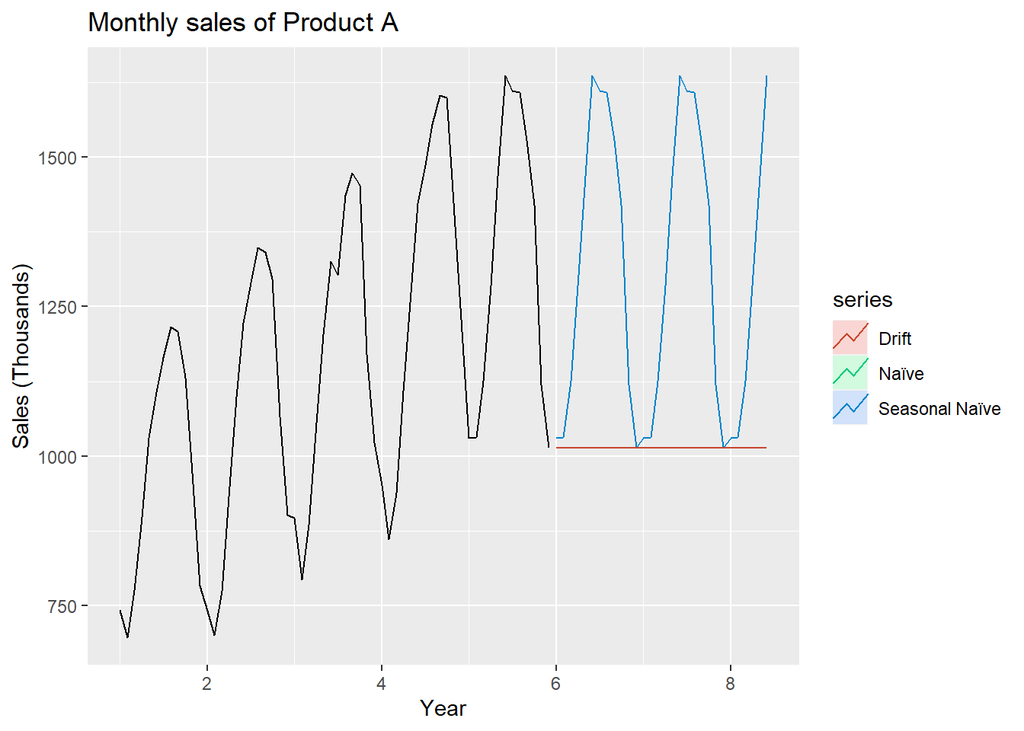

```r
autoplot(plastics, main="Monthly sales of Product A", ylab="Sales (Thousands)", xlab="Year") + autolayer(snaive(plastics, h=30), series="Seasonal Naïve", PI=FALSE) + autolayer(naive(plastics, h=30), series="Naïve", PI=FALSE) + autolayer(rwf(plastics, h=30), series="Drift", PI=FALSE)
```

`#` Question 2 (e)

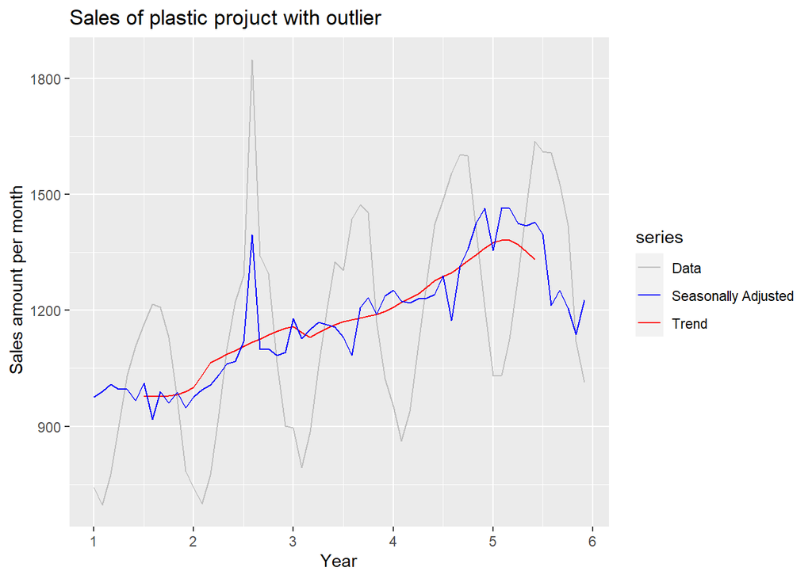

```r
plastics_new <- plastics
plastics_new[20] <- plastics_new[20] + 500
decompose_plastics_new <- decompose(plastics_new, type = "multiplicative"
                                    )
autoplot(plastics_new, series = "Data") +
  autolayer(trendcycle(decompose_plastics_new),
            series = "Trend") +

  autolayer(seasadj(decompose_plastics_new),
            series = "Seasonally Adjusted") +
  xlab("Year") +
  ylab(" Sales amount per month") +
  ggtitle("Sales of plastic projuct with outlier") +
  scale_color_manual(values=c("gray", "blue", "red"),
                     breaks=c("Data", "Seasonally Adjusted", "Trend"))
```

The outlier has small effect in the trend but also it has huge effect in the adjusted data

`#` Question 2 (F) Does it make any difference if the outlier is near the end rather than in the middle of the time series?

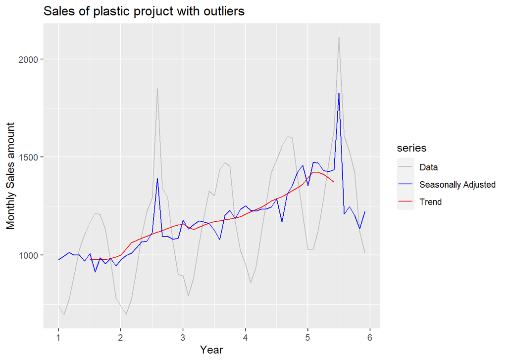

```r
plastics_new[55] <- plastics_new[55] + 500
decompose_plastics_new <- decompose(
  plastics_new,
  type = "multiplicative"
  )
autoplot(plastics_new, series = "Data") +
  autolayer(trendcycle(decompose_plastics_new),
            series = "Trend") +
  autolayer(seasadj(decompose_plastics_new),
            series = "Seasonally Adjusted") +
  xlab("Year") + ylab("Monthly Sales amount") +
  ggtitle("Sales of plastic projuct with outliers") +
  scale_color_manual(values=c("gray", "blue", "red"),
                     breaks=c("Data", "Seasonally Adjusted", "Trend"))
```

the effect to trend decreases when the outlier been more closer to the end in the plot.

## Question 3

Recall your retail time series data (from Exercise 3 in Section 2.10). Decompose the series using X11. Does it reveal any outliers, or unusual features that you had not noticed previously?

```r
library(seasonal)
library(readr)
tute1 <- read_csv("C:/Users/baaba/Downloads/tute1.csv")
```

```
## * `` -> ...1
```

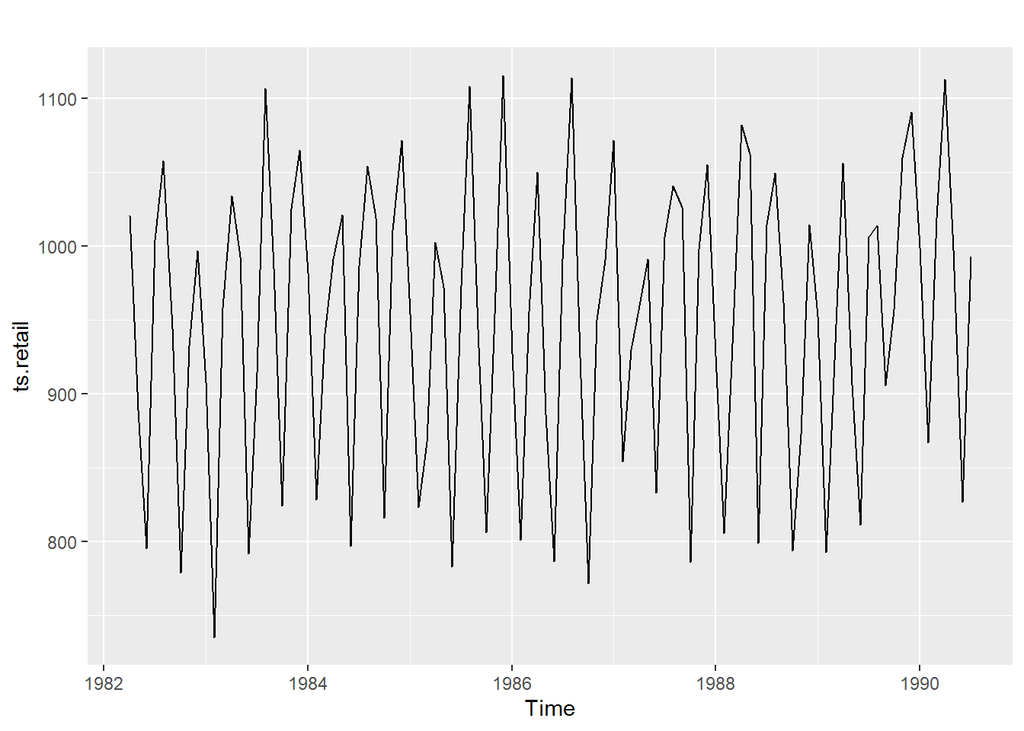

```r
ts.retail <- ts(tute1[,"Sales"],
                frequency=12,
                start=c(1982,4))

autoplot(ts.retail)
```

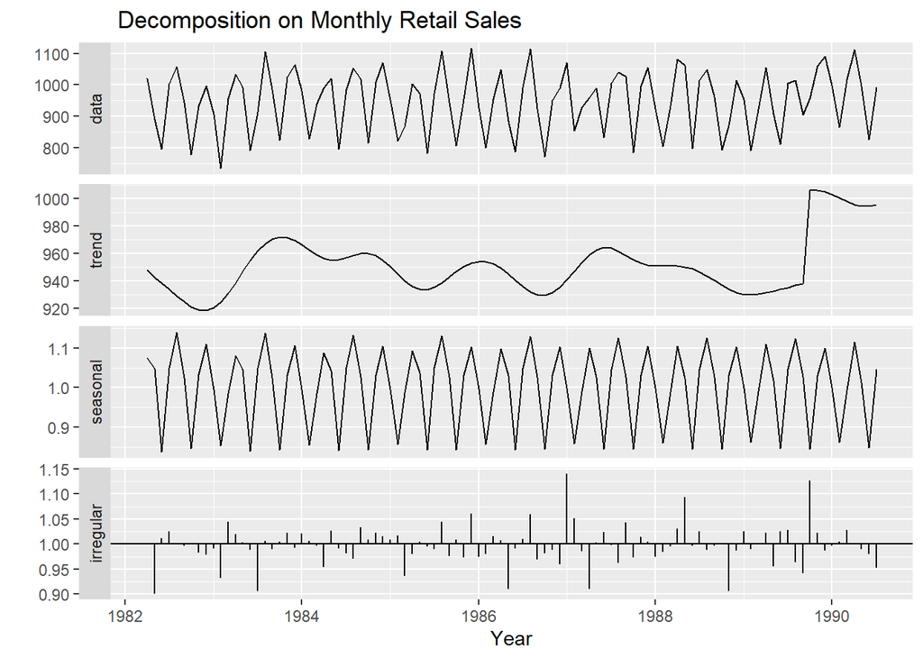

```r
retailx11 <- seas(ts.retail, x11="")

autoplot(retailx11, main=" Decomposition on Monthly Retail Sales", xlab="Year")
```

There are some big outliers especially the huge one around 1987 and at the end of 1989

## Question 4

`#` Question 4 (a) Write about 3–5 sentences describing the results of the decomposition. Pay particular attention to the scales of the graphs in making your interpretation.

`#` Question 4 (b) Is the recession of 1991/1992 visible in the estimated components?

## Question 5

This exercise uses the cangas data (monthly Canadian gas production in billions of cubic metres, January 1960 – February 2005).

`#` Question 5 (a) Plot the data using autoplot(), ggsubseriesplot() and ggseasonplot() to look at the effect of the changing seasonality over time. What do you think is causing it to change so much?

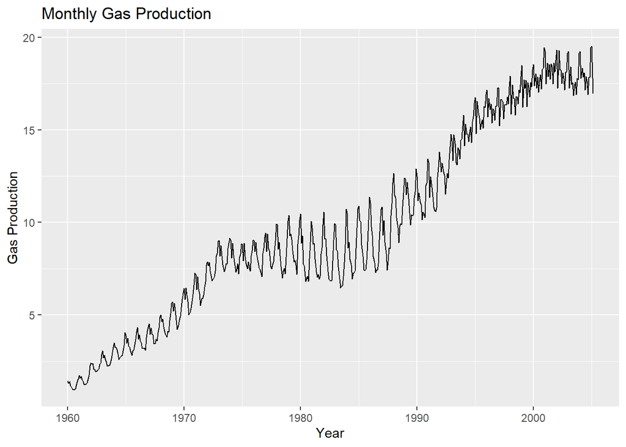

```r
autoplot(cangas, main="Monthly Gas Production", ylab="Gas Production", xlab="Year")
```

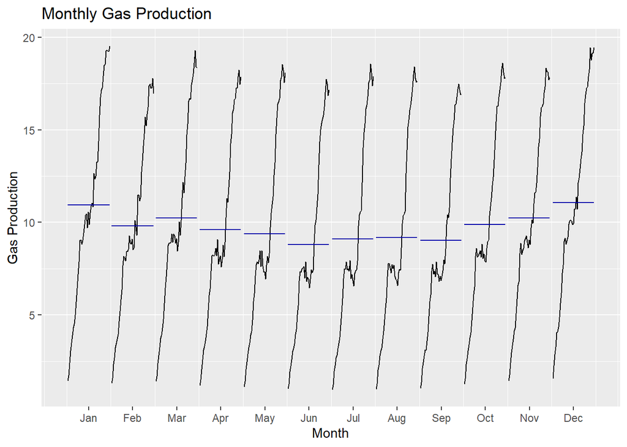

```r
ggsubseriesplot(cangas, main="Monthly Gas Production", ylab="Gas Production")
```

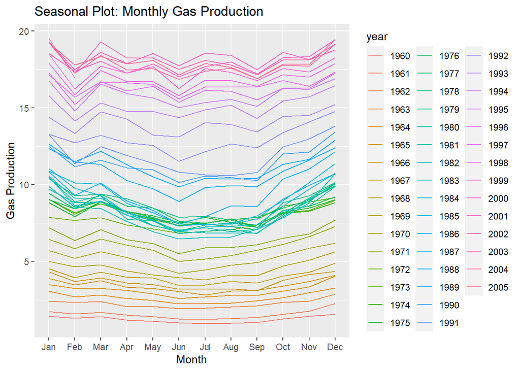

```r
ggseasonplot(cangas, main="Seasonal Plot: Monthly Gas Production", ylab="Gas Production")
```

`#` Question 5 (b) Do an STL decomposition of the data. You will need to choose s.window to allow for the changing shape of the seasonal component.

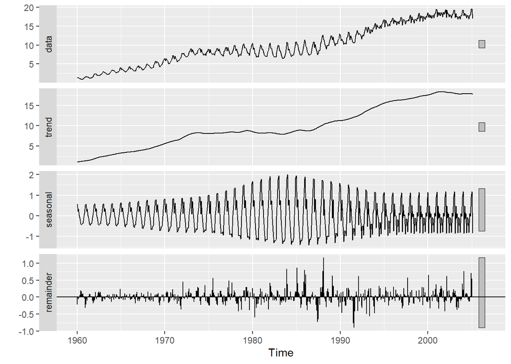

```r
stl_cangas <- stl(cangas, s.window = 13,
                  robust = TRUE)
# Show each STL decomposed component
autoplot(stl_cangas)
```

we can see that the seasonality increased in 1980s but it decreases after that in in 1990s